# COVID Response: a political battle

Brennan T. Beal, PharmD, MS

In keeping track of the political pundits, you can make a guess about the political leanings of a person simply by whether or not one thinks masks are a good idea. Unfortunately in such a polarized world, the words of our Governors and the President can have far-reaching health impacts. Because we now have amassed *a lot* of COVID-19 data, we can see if this is true to some extent.

This is strictly meant to be exploratry/hypothesis generating. I want to see how states are doing by red versus blue regarding cases. And then, if there is a difference, can we justify it as a difference in state-level behavior?

We'll mostly focus on cases since death is a lagging indicator and some function of cases and for behavior, the best data we have is Apple's Mobility data (more on that in a second).

### The Available Data

To look at how states are doing compared to their political counterparts, we need a few pieces of information:

1. State-level COVID-19 data
2. State voting history
3. State population data
4. State travel data

Fortunately for us, the [New York Times](https://www.nytimes.com/interactive/2020/us/coronavirus-us-cases.html) has published a really nice github repository tracking cases, deaths, and other metrics based on reports from state and local health agencies that we can use for our COVID-19 data.

For the state voting data, the process was a little less clear. First, how should we define a state's political leanings? There are a lot of states that we would consider swing states, or states that have a fairly unpredictable voting outcome cycle-to-cycle. Then, there are those with more predictable voting habits (Texas and California, for example). For the purposes of this analysis, I decided that I would use only states in the latter category. So, I chose states that had voted the same way, Republican or Democrat (red and blue, respecitvely), for at least the last four election cycles.

To gather this data, I used a website, [270towin](https://www.270towin.com/state-electoral-vote-history/) that has a nice repository of historical voting outcomes by state. We probably could've scraped the data but it was quicker to just the qualifying states into a data frame myself.

To properly assess individual states towards the beginning of the inquiry, I pulled 2019 census data from the [US Government's website](https://www.census.gov/data/tables/time-series/demo/popest/2010s-state-total.html#par_textimage_1574439295).

Finally, I have the [Apple Mobility data](https://www.apple.com/covid19/mobility), which is representative of Apple Map direction requests sent to the Apple servers as a percentage of baseline in January ("pre-COVID"). So, although this is very clearly not a perfect indication of travel, it should provide some pretty clear answers.

```r
# Here I'm just copying in data from the 270 to win website
# You can see all the states represented (plus D.C.)
state_voting_results <- data.frame(
  state = c("Alabama", "Alaska", "Arizona", "Arkansas", "California", "Conneticut", "Delaware",
            "District of Columbia", "Hawaii", "Georgia", "Idaho", "Illinois", "Kansas", "Kentucky", "Louisiana",
            "Maryland", "Massachusetts","Minnessota", "Mississippi", "Missouri", "Montana", "Nebraska",
            "New Hampshire", "New Jersey", "New York", "North Dakota", "Oklahoma", "Oregon", "Rhode Island",
            "South Carolina", "South Dakota", "Tennessee", "Texas",
            "Utah", "Vermont", "Washington", "West Virginia", "Wyoming"),
  vote  = c(rep("Red", 4), rep("Blue", 5), "Red", "Red", "Blue", rep("Red", 3),
            rep("Blue", 3), rep("Red", 4), rep("Blue", 3), rep("Red", 2),
            rep("Blue", 2), rep("Red", 5),
            rep("Blue", 2), rep("Red", 2))
)

# And state covid data from NYT: https://github.com/nytimes/covid-19-data
state_covid_data <- read.csv2("us-states.csv", sep = ",", header = TRUE) %>%
  # I noticed later that dates were read in as factors... classic.
  mutate(date = as.Date(date))

# --- 2019 Census Data (was fairly ugly data)
census <- read.csv("census.csv", header = TRUE)
names(census) <- c("state", "population") # change first name to lowercase state
census <- census[-1,] # remove first row, which was column title

census <- census %>%  # states have "." before them...
  mutate(state = str_remove(state, "."),
          # pop is a character with comma separating
         population = as.numeric(str_remove_all(population, ",")))

# Merge these all together by state:
full_df <- state_covid_data %>%
  left_join(., state_voting_results, by = "state") %>%
  left_join(., census, by = "state")
```

### Cases by Voting Habit

First, what are the states with the worst case numbers (per capita)? Let's just choose the top six. Also, from here on out, red and blue states will be red and blue, respectively, in the analysis.

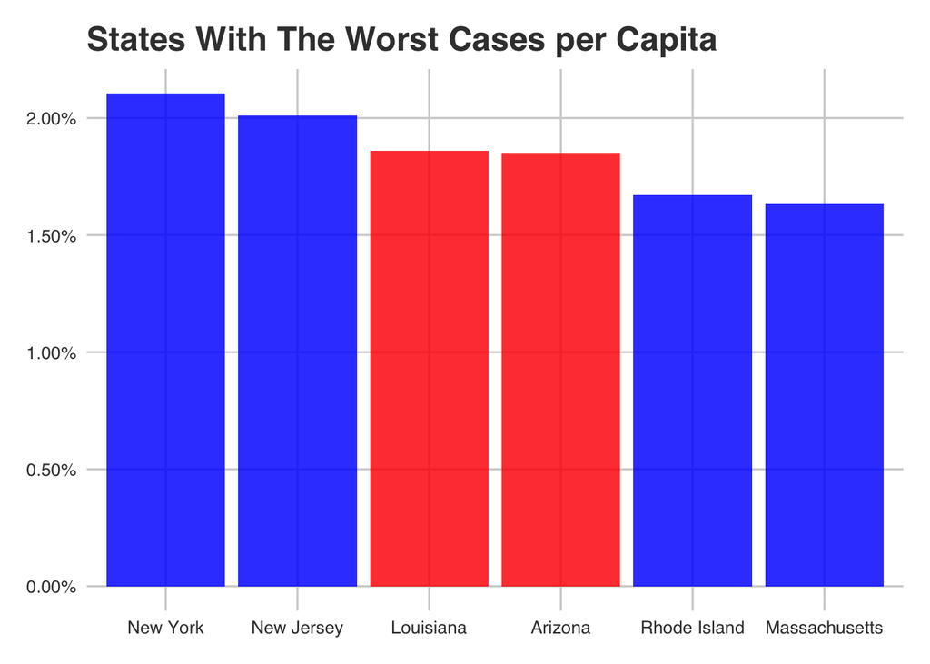

```r
top_totals <- full_df %>%
  # since they're cumulative cases,
  # we can just take the max number per state
  group_by(state) %>%
  mutate(tot_cases_per_population = max(cases)/population) %>%
  ungroup() %>%
  distinct(state, .keep_all = TRUE) %>%
  slice_max(tot_cases_per_population, n = 6)

# Plot them
ggplot(top_totals, aes(x = reorder(state, -tot_cases_per_population),
                       y = tot_cases_per_population,
                       fill = vote)) +
  geom_bar(stat = "identity", alpha = 5/6) +
  # love the fivethirtyeight theme
  #theme_fivethirtyeight() +
  # adding percentage labels
  scale_y_continuous(labels = scales::percent) +
  labs(
    title = "States With The Worst Cases per Capita"
  ) +
  guides(fill = FALSE) +
  scale_fill_manual(values = c("blue", "red"))
```

No big surprises here. The Northeast was hit fairly hard. Though, not to be bested, Arizona and Louisiana also found their way to the top. The main point here was to make sure that the states that have had the worst of COVID-19 are represented, which it seems like they are.

But I'm not necessarily worried about the case totals. A lot of states on both sides of the aisle were struggling to contain outbreak towards the beginning as the US tried to develop a containment strategy. I'm more so concerned about how states have been addressing things. My priors are that red states have taken things less seriously. Let's look at the top 3 states in both voting categories over time.

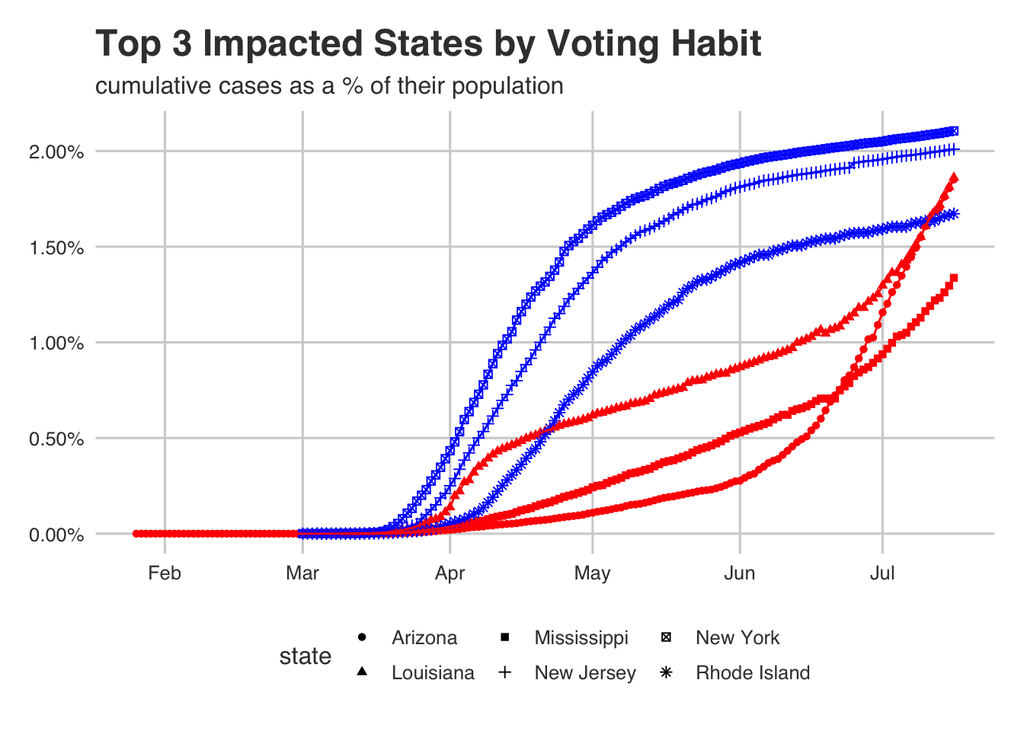

```r
top_3 <- full_df %>%
  # get rid of states w/ inconsistent voting
  filter(!is.na(vote)) %>%
  group_by(state) %>%
  mutate(tot_cases_per_population = max(cases)/population) %>%
  ungroup() %>%
  distinct(state, .keep_all = TRUE) %>%
  group_by(vote) %>%
  # take the top 3 cases per each voting type
  slice_max(tot_cases_per_population, n = 3) %>%
  # pull state out as a vector
  pull(state)

top_3_over_time <- full_df %>%
  # subset by top 3 states in each category
  filter(state %in% top_3) %>%
  mutate(case_per_pop = cases/population)

ggplot(top_3_over_time, aes(x = date, y = case_per_pop, color = vote, shape = state)) +
  geom_point() +
  geom_line() +
  scale_color_manual(values = c("blue", "red")) +
  #theme_fivethirtyeight() +
  scale_y_continuous(labels = scales::percent) +
  labs(
    title = "Top 3 Impacted States by Voting Habit",
    subtitle = "cumulative cases as a % of their population"
  ) +
  guides(color = FALSE)
```

This kind of gets at my prior assumptions. True, the top 3 blue states (states that I anticipated to have taken the pandemic more seriously), tend to have more cases per population. But what really matters in epidemiology is the *rate* of increase. How quickly people are getting infected. So, although the blue states have fared worse, they've managed to slow the spread substantially. Not sure what Arizona is doing.

Since we are concerned about the rate of increase, we should not be looking at totals. We should be looking at **log first differences**. Basically, this is a way to approximate the percent change from day to day (there are advantages to the approximation, which I won't go into here).

Jargon aside, I want to take a look at *rates* for the states above beginning around mid-April (when the whole "Seriously, wear a mask, please" conversation began). This should provide better information regarding the rate of disease spreading in red versus blue states.

Also note that this time series data has a lot of weekly fluctuation. I'll use a 7-day rolling average here to "smooth" the trend.

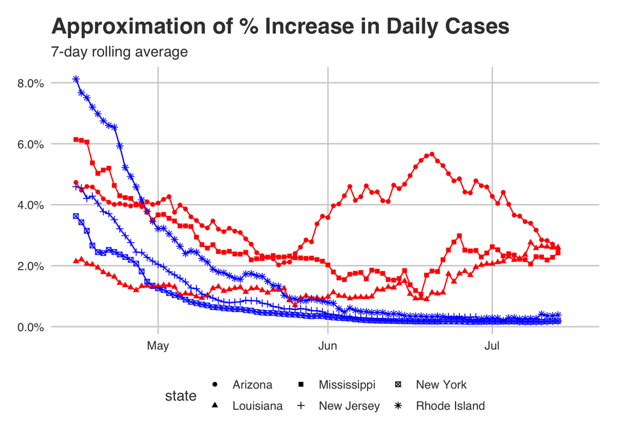

```r
top_3_lag_over_time <- full_df %>%
  # subset by top 3 states in each category
  filter(state %in% top_3) %>%
  # ensuring dates are unique for each state and if not, summing them
  group_by(state, date) %>%
  mutate(sum_cases = sum(cases)) %>%
  # Once summed, ensure dates are unique
  distinct(date, .keep_all = TRUE) %>%
  ungroup() %>%
  group_by(state) %>%
  arrange(date) %>%
  # log(firstdiff)
  # Reference: Community Use Of Face Masks And COVID-19:
  #     Evidence From A Natural Experiment Of State Mandates In The US
  mutate(lag_cases = (log(sum_cases) - lag(log(sum_cases))),
         # rolling average from the `zoo` package
         rolling_lag = rollmean(lag_cases, k = 7, fill = NA)) %>%
  filter(date > ymd("2020-04-15"))

ggplot(top_3_lag_over_time,
       aes(x = date, y = rolling_lag, color = vote, shape = state)) +
  geom_point() +
  geom_line() +
  scale_y_continuous(labels = scales::percent) +
  scale_color_manual(values = c("blue", "red"),
                     name = "Political Leaning") +
  #theme_fivethirtyeight() +
  labs(
    title = "Approximation of % Increase in Daily Cases",
    subtitle = "7-day rolling average"
  ) +
  guides(color = FALSE)
```

From the graph prior to this one (the one with Arizona blasting off), we could've probably inferred this graph. We see that Arizona has consistently large percent increase day-to-day over time. In addition, we see that the blue state's rate of infection is trending towards 0, even though the cases are still rising, slightly. Intuitively, this slope (or rate of change) describes how well one is containing the pandemic. There is a clear difference between the red and blue states.

If we put this all together, what does it look like? I'm going to sum the cumulative cases, by date, and then take the log first differences of those over time. We should then be able to see the rate of increase (generally) by red versus blue state.

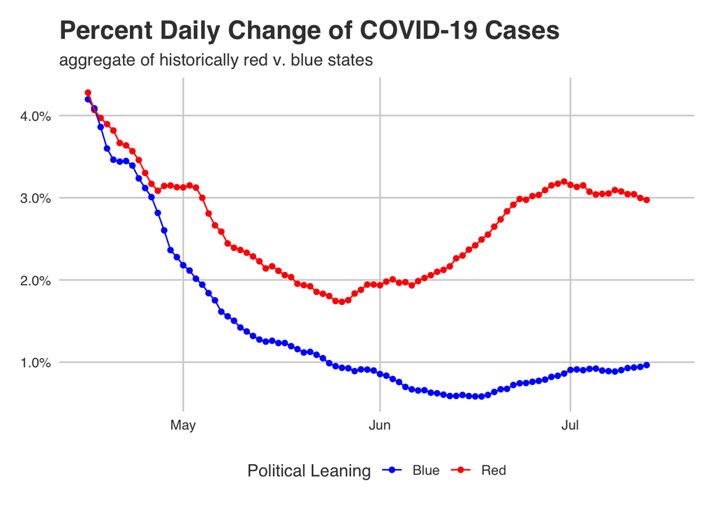

```r
vote_aggregated_data <- full_df %>%
  # get rid of states w/ inconsistent voting
  filter(!is.na(vote)) %>%
  # sum cases by dates and voting
  group_by(vote, date) %>%
  mutate(sum_cases = sum(cases)) %>%
  # Once summed, ensure dates are unique
  distinct(date, .keep_all = TRUE) %>%
  ungroup() %>%
  group_by(vote) %>%
  arrange(date) %>%
  # log(firstdiff)
  # Reference: Community Use Of Face Masks And COVID-19:
  #     Evidence From A Natural Experiment Of State Mandates In The US
  mutate(lag_cases = (log(sum_cases) - lag(log(sum_cases))),
         # rolling average from the `zoo` package
         rolling_lag = rollmean(lag_cases, k = 7, fill = NA)) %>%
  filter(date > ymd("2020-04-15"))

# ------- Plotting Data
ggplot(vote_aggregated_data, aes(x = date,  y = rolling_lag, color = vote)) +
  geom_point() +
  geom_line() +
  #theme_fivethirtyeight() +
  scale_y_continuous(labels = scales::percent) +
  scale_color_manual(values = c("blue", "red"),
                     name = "Political Leaning") +
  labs(
    title = "Percent Daily Change of COVID-19 Cases",
    subtitle = "aggregate of historically red v. blue states"
  )
```

It seems like both trends were relatively stable through the end of April - what happened then? I genuinely don't know. Perhaps red states began opening up more quickly?

There is actually one more piece of data we can look at to at least see if travel has gone up disproportionaly in red states around that time. We can take a peak at Apple's COVID-19 mobility [data](https://www.apple.com/covid19/mobility).

### Mobility by Voting Habit

First, let's pull all of the data an load it in.

```r
mobility_data <- read.csv2("applemobilitytrends.csv", sep = ",")

# Now, this data looks pretty rough...
# Going to subset based on our state voting data
# ----------- Subsetting Mobility Data for Areas of Interest
mobility_subset <- mobility_data %>%
  filter(sub.region %in% state_voting_results$state) %>%
  mutate(state = sub.region) %>%
  select(-sub.region) %>%
  # This was on the fly string manipulation... could've made this a bit neater
  pivot_longer(cols = contains("X"), names_to = "date", values_to = "Values") %>%
  mutate(date = gsub("X", "", date),
         date = gsub("\\.", "-", date),
         date = as.Date(date),
         Values = as.numeric(levels(Values))[Values])
```

Let's just look at the average data for all states over time...

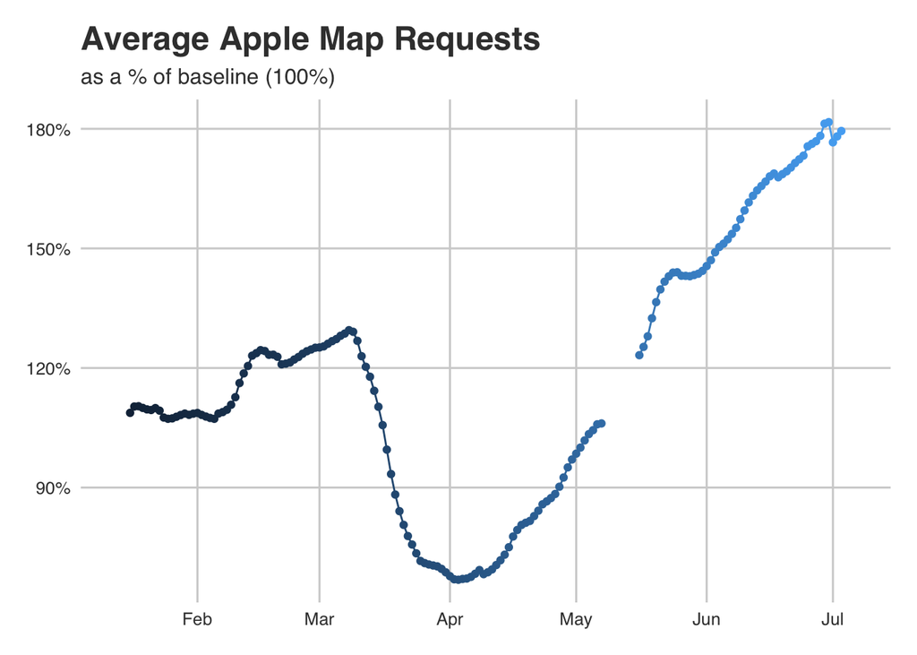

```r
mob_over_time <- mobility_subset %>%
  group_by(date) %>%
  # taking the averages, since these are percent fluctuation from baseline
  summarise(mean_value = mean(Values)) %>%
  # again, weekly trends smoothed
  mutate(rolled_values = rollmean(mean_value, k = 7, fill = NA))


ggplot(mob_over_time, aes(x = date, y = rolled_values/100, color = date)) +
  geom_point() +
  geom_line() +
  scale_y_continuous(labels = scales::percent) +
  labs(
    title = "Average Apple Map Requests",
    subtitle = "as a % of baseline (100%)"
  ) +
  guides(color = FALSE)
```

Are there any difference in traveling around mid-April for each of our groups?

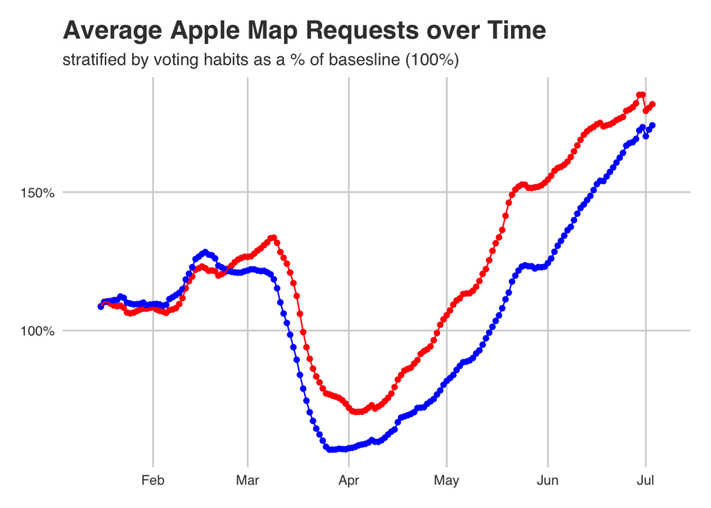

```r
vote_mobility <- mobility_subset %>%
  left_join(., state_voting_results, by = "state") %>%
  group_by(vote, date) %>%
  summarise(mean_value = mean(Values))

# We should impute the subsets then re-bind them for plotting
# not going to comment all this... using kalman imputation for each subset
# -- not sure how to do this with dplyr so hitting it with the old fashion R
red_sub <- vote_mobility %>%
  filter(vote == "Red")
red_subts <- ts(red_sub$mean_value)
red_imputed <- na_kalman(red_subts)
red_rebound <- cbind(imp = red_imputed[1:length(red_imputed)], red_sub)


blue_sub <- vote_mobility %>%
  filter(vote == "Blue")
blue_subts <- ts(blue_sub$mean_value)
blue_imputed <- na_kalman(blue_subts)
blue_rebound <- cbind(imp = blue_imputed[1:length(blue_imputed)], blue_sub)

vote_imputed <- rbind(red_rebound, blue_rebound) %>%
  group_by(vote) %>%
  mutate(rolled_imp_values = rollmean(imp, k = 7, fill = NA))

ggplot(vote_imputed, aes(x = date, y = rolled_imp_values/100, color = vote)) +
  geom_point() +
  geom_line() +
  scale_y_continuous(labels = scales::percent) +
  scale_color_manual(values = c("blue", "red"))  +
  labs(
    title = "Average Apple Map Requests over Time",
    subtitle = "stratified by voting habits as a % of basesline (100%)"
  ) +
  guides(color = FALSE)
```

What I gather from this is that the red states, on average, took the whole lockdown issue a bit less seriously. That said, both groups returned at about the same rate from their minimums - BACK TO OVER 150% OF BASELINE.

So, it looks like travel may be part of the difference we're seeing but no doubt not the whole story.

In the long run, this doesn't look good for any of us.

### Conclusion

What we've seen is that at first glance, blue states have generally had the worst of the COVID-19 cases as a percentage of their population. But the bigger picture is containment strategy. From the rates of infection, we can see that red states are poised to begin dominating the conversation surrounding failed containment.

We can see that on average, red states took lockdown precautions less seriously but this is likely a very small part of the story.

Ultimately, by the looks of our travel data, and a most recent look at the second wave, all states will continually be negatively impacted until we can get full buy-in from all leaders involved.